# Análisis de Datos I Tarea 11

# Liberías

```r
library(readr)
library(kableExtra)
library(dplyr)
```

# Pregunta 1

**Complete las demostraciones de los Teoremas 2 y 4 de la presentación de la clase.**

## Teorema 2

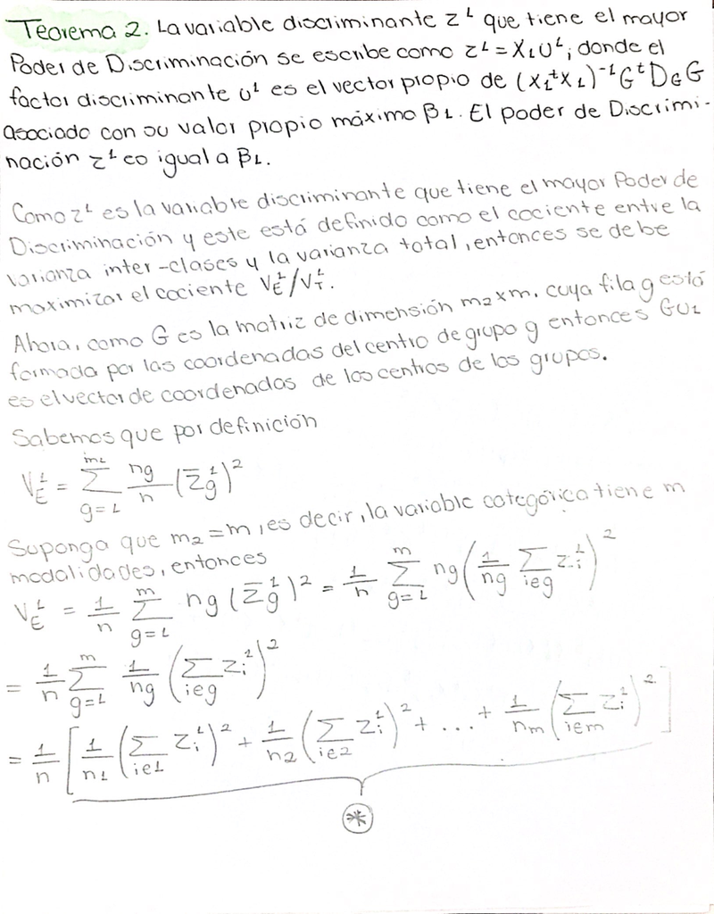

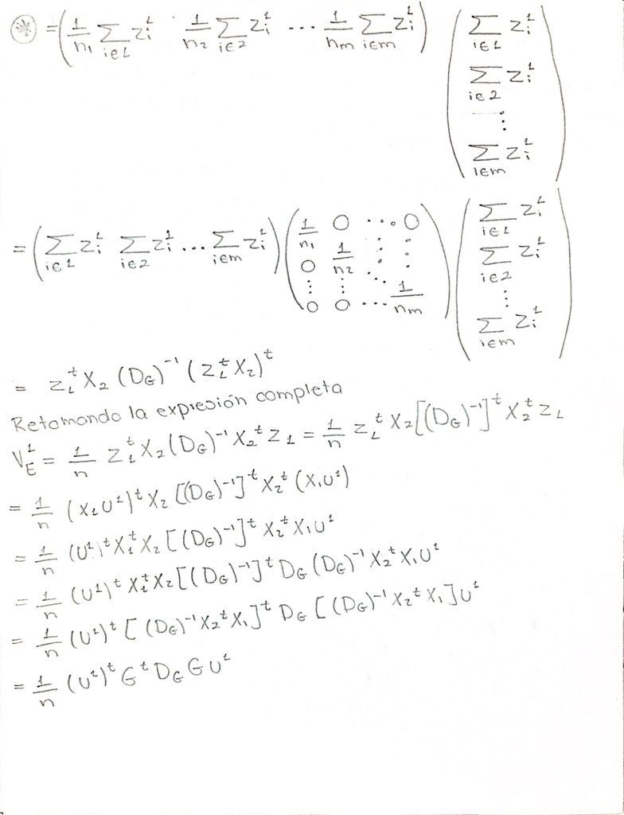

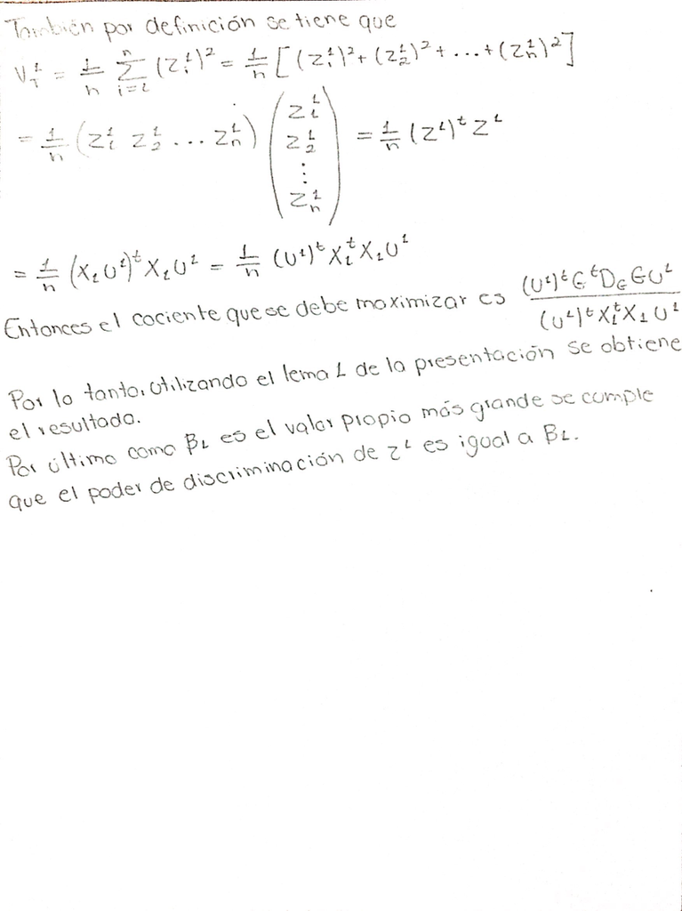

## Teorema 4

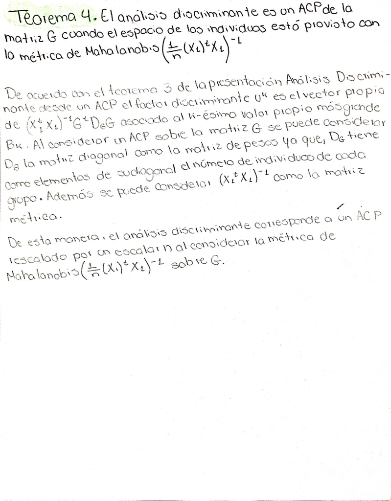

# Pregunta 4

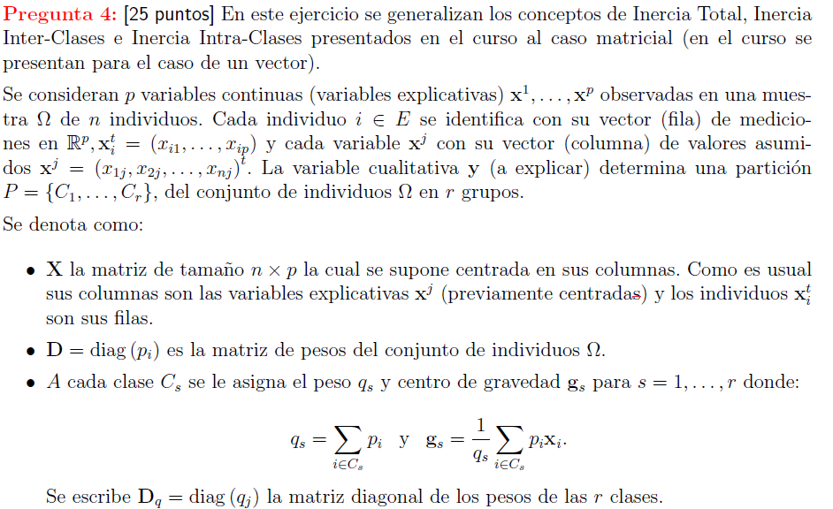

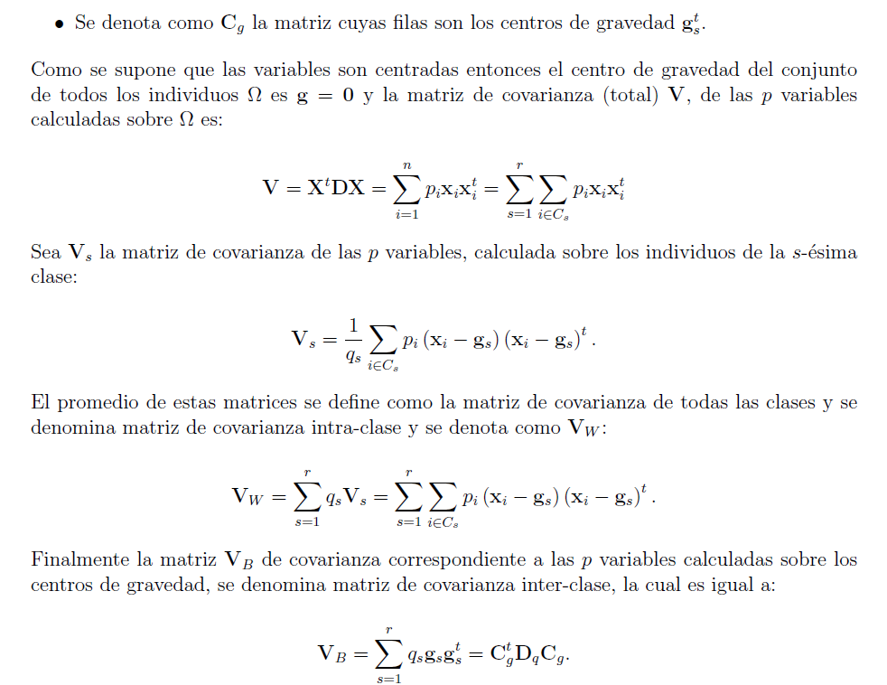

**Con las definiciones anteriores pruebe lo siguiente: Si V;VB;VW son las matrices de covarianza total, inter-clase intra-clase, respectivamente, entonces:**

**1. V = VB + VW**

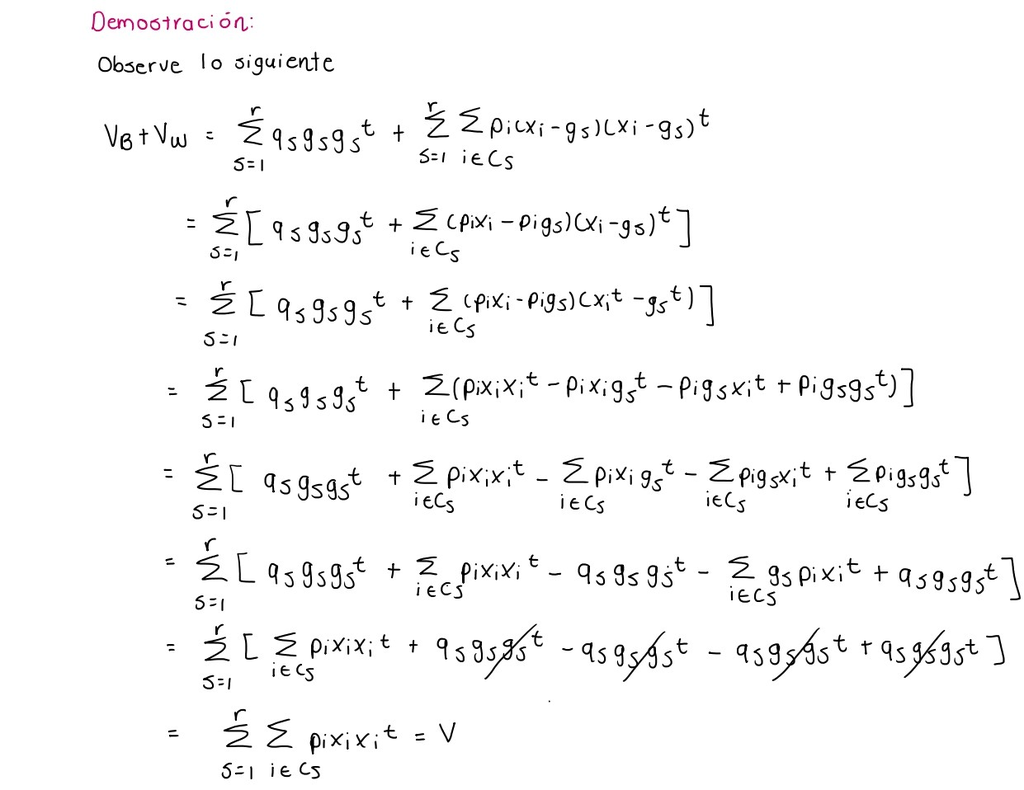

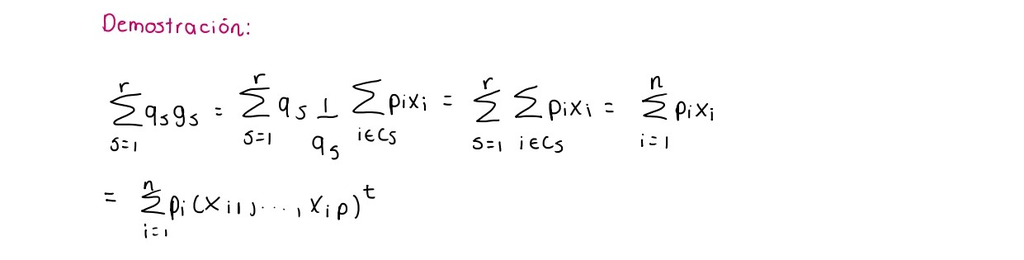

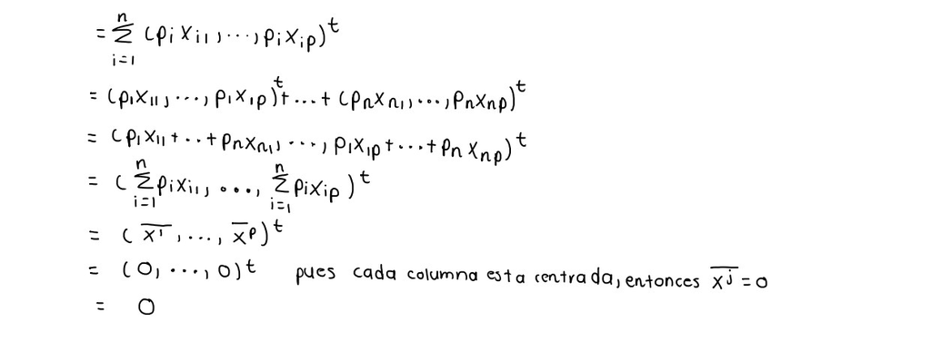

**Además, para la tabla de datos Ejemplo AD.csv calcule: gA, gB, gC, V, VB, VW y verifique que V = VB + VW**

Primeramente, se carga la base de datos

```r
Ejemplo_AD <-read.csv("Ejemplo_AD.csv",sep = ";",dec='.',header=T,row.names = 1,stringsAsFactors = T)
```

Las columnas de variables númericas deben estar centradas, por lo que, la media de cada una debe ser cero. Verifiquemos si lo están:

```r
colMeans(Ejemplo_AD[,-6])
```

```
##       RT1       RT2       RT3       RT4       RT5
##  7.213333  5.746667  1.950000  0.710000 21.740000
```

Se puede observar que las medias de cada columna númerica son diferente de cero, por lo que, debemos centrarlos de la siguiente manera:

```r
for(i in 1: (ncol(Ejemplo_AD)-1)) {
  Ejemplo_AD[,i] <- Ejemplo_AD[,i]-mean(Ejemplo_AD[,i])
}

head(Ejemplo_AD)
```

```
##           RT1        RT2   RT3   RT4   RT5 VC
## A1  1.7866667 -1.1466667  0.05 -0.61  4.06  A
## B1 -3.2133333 -2.4466667 -1.55 -0.11 10.66  B
## C1 -5.8133333 -4.7466667 -0.85 -0.21  1.76  C
## A2  2.7866667  0.9533333  1.95 -0.51 -6.04  A
## B2  0.9866667  0.4533333  0.15 -0.51 -4.74  B
## C2 -4.7133333 -0.3466667 -1.15 -0.31 -5.44  C
```

Se obtienen los dos juegos de datos con las que se trabajan, la primera con variables númericas y la segunda con el código disyuntivo completo de las modalidades de la variable categórica.

```r
X <- data.matrix(Ejemplo_AD)

# Datos con las variables númericas
X1<- X[,-6]
head(X1)
```

```
##           RT1        RT2   RT3   RT4   RT5
## A1  1.7866667 -1.1466667  0.05 -0.61  4.06
## B1 -3.2133333 -2.4466667 -1.55 -0.11 10.66
## C1 -5.8133333 -4.7466667 -0.85 -0.21  1.76
## A2  2.7866667  0.9533333  1.95 -0.51 -6.04
## B2  0.9866667  0.4533333  0.15 -0.51 -4.74
## C2 -4.7133333 -0.3466667 -1.15 -0.31 -5.44
```

El segundo juego de datos es:

```r
# Datos con las variables categóricas
VC.A <- as.numeric(Ejemplo_AD$VC == "A")
VC.B <- as.numeric(Ejemplo_AD$VC == "B")
VC.C <- as.numeric(Ejemplo_AD$VC == "C")

X2 <- cbind(VC.A,VC.B,VC.C)
head(X2)
```

```
##      VC.A VC.B VC.C
## [1,]    1    0    0
## [2,]    0    1    0
## [3,]    0    0    1
## [4,]    1    0    0
## [5,]    0    1    0
## [6,]    0    0    1
```

Luego, se calcula matriz $D_g$ diagonal del número de individuos en cada modalidad.

```r
D_G <- table(Ejemplo_AD$VC,Ejemplo_AD$VC)
D_G
```

```
##
##      A  B  C
##   A 10  0  0
##   B  0 10  0
##   C  0  0 10
```

Ahora, se obtienen los centros de gravedad de A, B y C.

$g_A$

```r
# Matriz cuyas filas son los centros de gravedad
G <- solve(D_G) %*% t(X2) %*% X1

gA <- G[1,]
gA
```

```
##        RT1        RT2        RT3        RT4        RT5
##  3.6866667  0.8433333  1.3400000 -0.3500000 -0.4000000
```

$g_B$

```r
gB <- G[2,]
gB
```

```
##         RT1         RT2         RT3         RT4         RT5
## -0.51333333  0.09333333 -0.21000000  0.25000000  0.48000000
```

$g_C$

```r
gC <- G[3,]
gC
```

```
##        RT1        RT2        RT3        RT4        RT5
## -3.1733333 -0.9366667 -1.1300000  0.1000000 -0.0800000
```

Seguido, se procede a calcular la matriz de covarianzas total $V$.

```r
# Matriz de pesos del conjuntos de individuos de la matriz X1
peso <-1/nrow(X1)
pesos_ind <- diag(peso, nrow(X1))

V <- t(X1)%*%pesos_ind %*%X1
kable_styling(kable(V))
```

|  | RT1 | RT2 | RT3 | RT4 | RT5 |
| --- | --- | --- | --- | --- | --- |
| RT1 | 10.8924889 | 1.1097111 | 3.328667 | -0.6114667 | -3.081200 |
| RT2 | 1.1097111 | 10.8398222 | 2.405000 | 0.4715333 | -4.521533 |
| RT3 | 3.3286667 | 2.4050000 | 1.915833 | -0.1175000 | -2.416667 |
| RT4 | -0.6114667 | 0.4715333 | -0.117500 | 0.5929000 | 1.017933 |
| RT5 | -3.0812000 | -4.5215333 | -2.416667 | 1.0179333 | 17.267067 |

La matriz de covarianzas inter-clase $V_B$ es:

```r
# Matriz diagonal de pesos de las 3 clases
pesos_clases <- D_G*peso

VB <- t(G)%*%pesos_clases%*%G
kable_styling(kable(VB))
```

|  | RT1 | RT2 | RT3 | RT4 | RT5 |
| --- | --- | --- | --- | --- | --- |
| RT1 | 7.9750222 | 2.0111778 | 2.8779333 | -0.5786667 | -0.4890667 |
| RT2 | 2.0111778 | 0.5324222 | 0.7229667 | -0.1218333 | -0.0725333 |
| RT3 | 2.8779333 | 0.7229667 | 1.0388667 | -0.2115000 | -0.1821333 |
| RT4 | -0.5786667 | -0.1218333 | -0.2115000 | 0.0650000 | 0.0840000 |
| RT5 | -0.4890667 | -0.0725333 | -0.1821333 | 0.0840000 | 0.1322667 |

La matriz de covarianzas intra-clase $V_W$ es:

```r
clases <- unique(Ejemplo_AD$VC)

# Se calcula la matriz VW
VW <- matrix(0, nrow = 5, ncol = 5)

for(i in (1:length(clases))) {
  clase <- Ejemplo_AD[Ejemplo_AD$VC == clases[i], -6]
  n <- nrow(clase)

  # Calcular la suma para la clase actual
  suma <- matrix(0, nrow = 5, ncol = 5)
  for(j in 1: n){
    xi_minus_g <- as.numeric(clase[j,] - G[i,])
    suma <- suma + xi_minus_g%*%t(xi_minus_g)
  }
  VW <- VW + suma
}
VW <- peso*VW
kable_styling(kable(VW))
```

| 2.9174667 | -0.9014667 | 0.4507333 | -0.0328000 | -2.5921333 |
| --- | --- | --- | --- | --- |
| -0.9014667 | 10.3074000 | 1.6820333 | 0.5933667 | -4.4490000 |
| 0.4507333 | 1.6820333 | 0.8769667 | 0.0940000 | -2.2345333 |
| -0.0328000 | 0.5933667 | 0.0940000 | 0.5279000 | 0.9339333 |
| -2.5921333 | -4.4490000 | -2.2345333 | 0.9339333 | 17.1348000 |

Verificamos que se cumple $V = V_B+V_W$.

```r
kable_styling(kable(VB+VW))
```

|  | RT1 | RT2 | RT3 | RT4 | RT5 |
| --- | --- | --- | --- | --- | --- |
| RT1 | 10.8924889 | 1.1097111 | 3.328667 | -0.6114667 | -3.081200 |
| RT2 | 1.1097111 | 10.8398222 | 2.405000 | 0.4715333 | -4.521533 |
| RT3 | 3.3286667 | 2.4050000 | 1.915833 | -0.1175000 | -2.416667 |
| RT4 | -0.6114667 | 0.4715333 | -0.117500 | 0.5929000 | 1.017933 |
| RT5 | -3.0812000 | -4.5215333 | -2.416667 | 1.0179333 | 17.267067 |

Se puede notar que la suma de esas matrices es igual a $V$.